# Equivalence models

Vanessa Ferdinand

7/2/2020

## *Draft 1 - document still in progress*

# Overview

[Reali & Griffiths (2010)](https://royalsocietypublishing.org/doi/pdf/10.1098/rspb.2009.1513) describe an equivalence between the Wright-Fisher model of drift and a Bayesian model of regularization. This document is a tutorial on some components of that equivalence.

Two things to look for:  
1) Where are the means?  
2) How is the error distributed? (i.e. what’s the distribution around the mean?)

Original citations for the Wright-Fisher model:  
Fisher, R. A. (1930). *The genetical theory of natural selection.* Oxford, UK: Clarendon Press.  
Wright, S. (1931). Evolution in Mendelian populations. *Genetics* **16**, 97–159.

## Wright Fisher drift with mutation

2 allele model with symmetrical mutation

There are 2 alleles or *variants*, $v_1$ and $v_2$, in a population of size $N$.

The *frequency* of $v_1$ in the population is $q$ and the frequency of $v_2$ is $1-q$.

The mutation rate is $\mu$. We assume all mutatants of $v_1$ become $v_2$ and all mutatants of $v_2$ become $v_1$. So $\mu = p(v_1 \rightarrow v_2) = p(v_2 \rightarrow v_1)$.

TO DO: add explanation of WF drift model

Point: we’re gonna look at evolutionary models in terms of how the frequency of genotypes change in one generation. That’s the first plot below. Dashed line shows no change of frequencies. Everything off that line is a change in frequencies. Solid line is the change in frequencies (of variant $v_1$) under the WF model with mutation. Go in the R code and change the mutation parameter `mu` a.k.a $\mu$ and see how the plot changes.

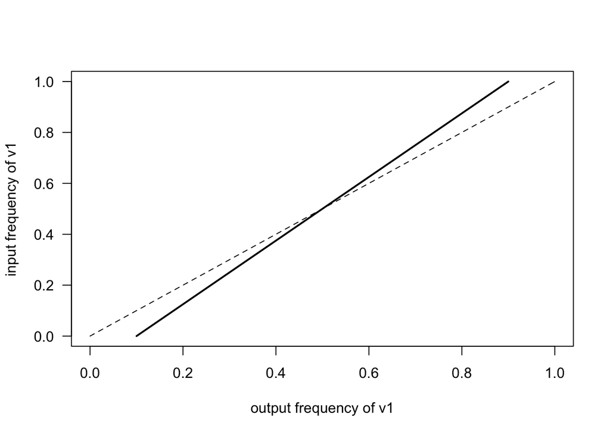

```r
# TO DO explain this code
WF_mutation_TP <- function(in_p,out_p,N,mu) {
    theta_substitute <- (in_p*(1-mu))+((1-in_p)*mu)  # this is the mean
    out_k <- out_p*N  # out_p*N converts out_p to k
    left = choose(N,out_k)  # these remaining lines add binomial noise around the mean
    middle = theta_substitute**out_k
    right = (1-theta_substitute)**(N-out_k)
    return(left * middle * right)
}

# TO DO explain this code
WF_expected_change <- function(in_p,N,mu) {
    losses <- in_p*(1-mu)  # what v1 loses due to mutation
    gains <- (1-in_p)*mu # what v1 gains from v2's losses
    return(gains+losses)
}

WF_expected_change_plotter <- function(N,mu) {
    qt1 <- seq(0,1,by=.01)  # all possible frequencies of v1 in generation t (resolution = by)
    qt2 <- WF_expected_change(qt1,N=10,mu)  # new frequency of v1 in generation t+1
    plot(qt2,qt1,las=1,type="l",lwd=2,ylab="input frequency of v1",
         xlab="output frequency of v1",xlim=c(0,1),ylim=c(0,1))
    lines(qt1,qt1,lty="dashed",lwd=1)
}

mu <- 0.1 # set the mutation rate to whatever you want
WF_expected_change_plotter(10,mu)
```

## Bayesian model described in Reali & Griffiths 2010

See [this tutorial](https://htmlpreview.github.io/?https://github.com/vanferdi/iso_projects/blob/master/drift/Bayes_regularization_model.html) for an in-depth explanation of how this model works.

#### Choose a prior

The prior is a beta distribution with parameters $Beta(\alpha,\beta)$. When $\alpha = \beta$ the prior is symmetrical, when $\alpha \neq \beta$, it’s not.

Choose whatever $\alpha$ and $\beta$ you want and plot the resulting prior:

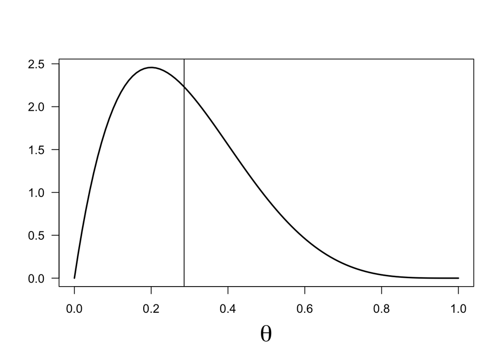

```r
alpha <- 2  # 2
beta <- 5  # 5

beta_mean <- function(alpha,beta) { return(alpha/(alpha+beta)) }

x <- seq(0, 1, length=100)
y <- dbeta(x,alpha,beta)  # this is the beta ditribution
plot(x, y, type="l", las=1, lwd=2, xlab=bquote(theta), ylab="", cex.lab=2)
abline(v=beta_mean(alpha,beta)) # also plot the mean
```

#### Solve the posterior, given some data

How to solve the posterior distribution in the beta-binomial Bayesian model. This is so simple coz of the conjugate prior.

Plot the posterior distribution for any prior and any hypothetical data:

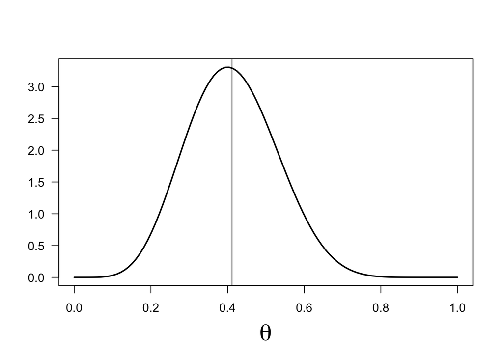

```r
k <- 5        # number of observations where the outcome = v1
N <- 10       # total number of observations (N must be larger than k)

alpha <- 2    # parameters of prior
beta <- 5

posterior_mean <- beta_mean(alpha+k,beta+N-k)  # here's the mean of the posterior
x <- seq(0, 1, length=100)                     # compute dbeta() for these values of theta
y <- dbeta(x,alpha+k,beta+N-k)                 # this is the posterior distribution
plot(x, y, type="l", las=1, lwd=2, xlab=bquote(theta), ylab="", cex.lab=2)
abline(v=posterior_mean)
```

**Conjugate prior**  
As you’ve noticed, solving the posterior is incredibly easy. It’s easy because the beta distribution is a [conjugate prior](https://en.wikipedia.org/wiki/Conjugate_prior) of the binomial likelihood. You just straightup add the data parameters to the prior parameters – and the resulting beta distribution is the posterior distribution. If the prior is $Beta(\alpha,\beta)$, then the posterior is $Beta(\alpha+k,\beta+N-k)$.

**Common interpretation**  
It’s like the prior adds extra data points (or *pseudo-observations*) to the ones you observed (weighting your observations by your beliefs). In other words, it’s like the value of $\alpha$ are extra observations of $v_1$ and the value of $\beta$ are extra observations of $v_2$.

**A weirdness**  
Based on the common interpretation above, you’d expect the prior that adds *no information* to the data seen would be the uniform prior, right? Well the prior that adds no pseudo-observations to the data is the distribution where $Beta(\alpha=0,\beta=0)$. And that’s the maximally U-shaped prior. The uniform, or un-biased, prior actually adds one pseudo-observation to each data type ($v_i$) as in $Beta(\alpha=1,\beta=1)$.

#### Plot the change in mean frequency of $v_1$

Here’s the basic population genetics plot again, where we look at how the mean frequency of $v_1$ changes in one generation.

If the agent chooses the average hypothesis and samples data from that hypothesis, the data will be distributed according to the binomial likelihood function $p(k|N,\theta) = {N \choose k} p^k (1-p)^{N-k}$. The mean of a binomial distribution always $= N\theta$.

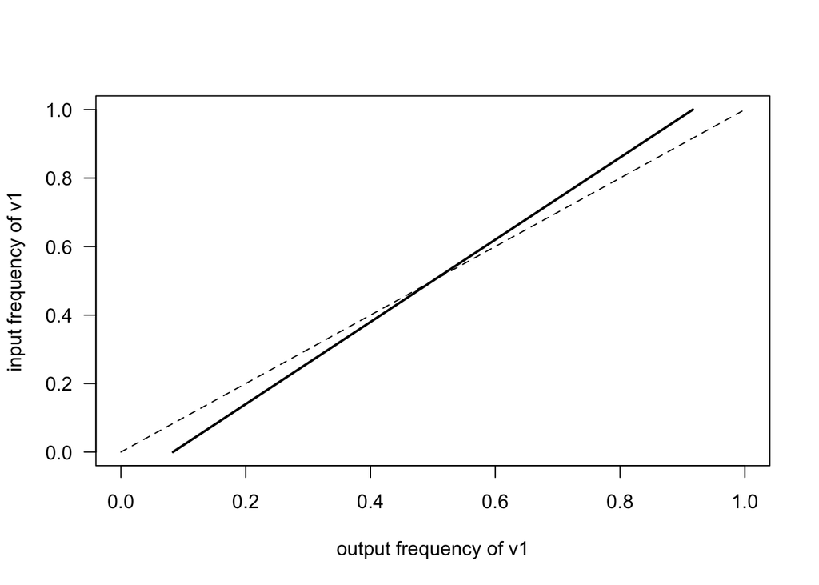

```r
N <- 10             # sample size
k <- seq(0,N, by=1) # for all possible input frequencies of v1

alpha <- 1    # parameters of prior
beta <- 1

posterior_mean <- beta_mean(alpha+k,beta+N-k)  # agents choose this hypothesis
v1_mean_frequency <- N*posterior_mean          # binomial mean for each theta=posterior_mean

# now normalize all frequencies by N so q(v1) falls between 0 and 1
input_q <- k/N
output_q <- v1_mean_frequency/N

# plot change in mean frequency of v1
plot(output_q,input_q,las=1,type="l",lwd=2,ylab="input frequency of v1",xlab="output frequency of v1",xlim=c(0,1),ylim=c(0,1))
lines(input_q,input_q,lty="dashed",lwd=1)
```

K now put the code above into functions so we can use them again later:

```r
RG_expected_change <- function(N,alpha,beta) {
    k <- seq(0,N, by=1)
    posterior_mean <- beta_mean(alpha+k,beta+N-k)
    v1_mean_frequency <- N*posterior_mean
    input_q <- k/N
    output_q <- v1_mean_frequency/N
    return(list(input_q,output_q))
}

# example usage:
# result <- RG_expected_change(100,10,10)
# input_q <- result[[1]]
# output_q <- result[[2]]

RG_expected_change_plotter <- function(N,alpha,beta) {
    result <- RG_expected_change(N,alpha,beta)
    plot(result[[2]],result[[1]],las=1,type="l",lwd=2,ylab="input frequency of v1",
         xlab="output frequency of v1",xlim=c(0,1),ylim=c(0,1))
    lines(result[[1]],result[[1]],lty="dashed",lwd=1)
}

# example usage:
# RG_expected_change_plotter(10,1,1)
```

## Solution

RG2010 state:  
“for each value of mutation rate u, there exists values of a and K satisfying the condition for equivalence” (p. 432)

That means, for every WF model with parameter $\mu$, there is an equivalent Bayesian beta-binomial model - you just gotta choose the right paramters of $\frac{a}{2}$, $K$, and $N$.

They state how these parameters relate to $\mu$:

$\mu = \big(\frac{\alpha/V-1}{\alpha+N}\big)V$

They stopped at this mathematical statement and didn’t provide any further intuition or visualizations - so let’s do that here.

TO DOs

Plot example of two equivalent models and state params.

How does $\mu$ vary with $\alpha$?

How does $\mu$ vary with $K$?

How does $\mu$ vary with $N$?

## Asymmetrical priors

Ok everyhting in this section is new and wasn’t in RG2010. They worked everything out for symmetrical priors. In this section, I’m gonna work stuff out for asymmetrical priors.

Now let’s look at the freq change plot for an asymmetrical prior:

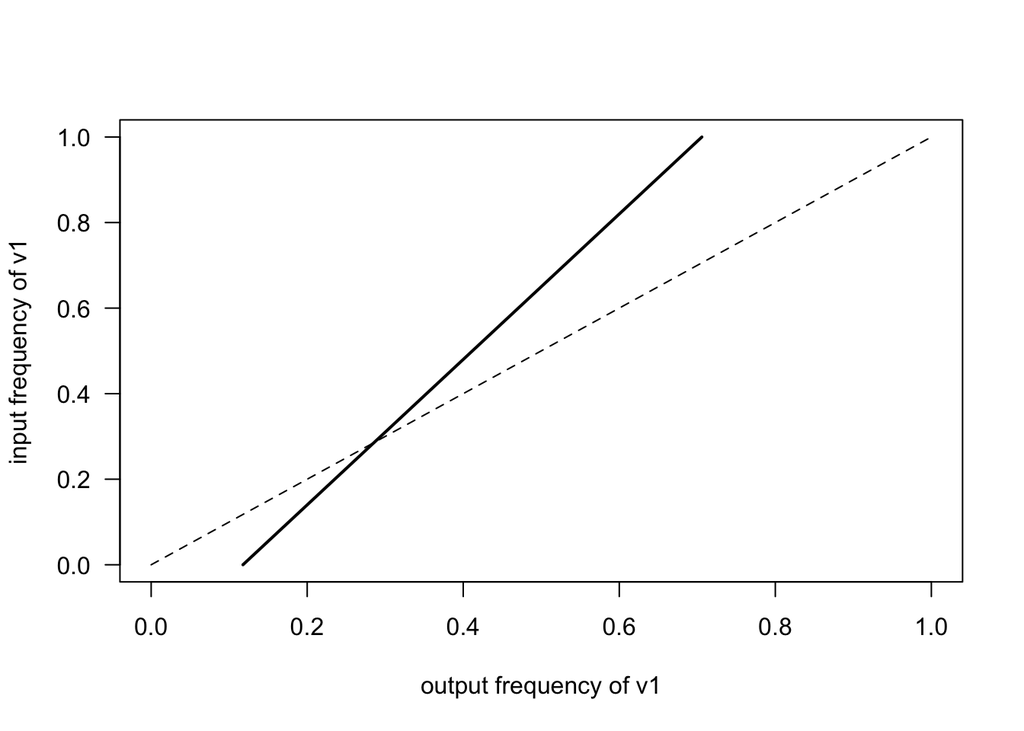

```r
RG_expected_change_plotter(10,2,5)
```

Here’s what stands out:  
1) The solid line is still straight, meaning its still some kind of mutation.  
2) The pivot point is NOT $= 0.5$.

#### Demonstration 1:

For all $\alpha = \beta$, the intersection between the dotted line and the solid line is $(0.5,0.5)$.

Get pivot points for a range of symmetrical priors:

```r
pivot_point <- function(array1,array2) {
    ans <- array1[which(array1==array2,TRUE)] # find where input q = output q
    return(ans)
}

# example usage:
# pivot_point(input_q,output_q)

N <- 10
alpha_range <- seq(0,10,by=.1)
alpha_range <- alpha_range[-1]  # remove zero

pivot_points <- c() # save all pivot points here
for (a in alpha_range) {
    result <- RG_expected_change(N,a,a)
    pp <- pivot_point(result[[1]],result[[2]])
    pivot_points <- c(pivot_points,pp)
}

unique(pivot_points) # the only result is 0.5, meaning 0.5 is the only pivot point
```

```
## [1] 0.5
```

#### Demonstration 2:

For all $\alpha \neq \beta$, the intersection between the dotted line and the solid line is $\neq 0.5$.

```r
pivot_point(input_q,output_q)
```

```
## [1] 0.5
```

Get pivot points for a range of asymmetrical priors:

K THIS DOESN’T WORK bcause the equality can occur in the cracks of the range we’re sampled

```r
N <- 10
alpha_range <- seq(0,10,by=1)
alpha_range <- alpha_range[-1]  # remove zero
beta_range  <- alpha_range      # use same range for beta

pivot_points <- c() # save all pivot points here
alpha_values <- c() # save correponding alpha value here
beta_values <- c()  # save correponding beta value here
counter <- 0
for (a in alpha_range) {
    for (b in beta_range) {
        result <- RG_expected_change(N,a,b)
        pp <- pivot_point(result[[1]],result[[2]])
        counter <- counter+1
        pivot_points <- c(pivot_points,pp)
        alpha_values <- c(alpha_values,a)
        beta_values <- c(beta_values,b)
    }
}

df <- cbind(alpha_values,beta_values,pivot_points)
```

## Scratch

#### Postive and negative mutation rates

Making a mutation rate negative flips the results horizonally about the dashed line.

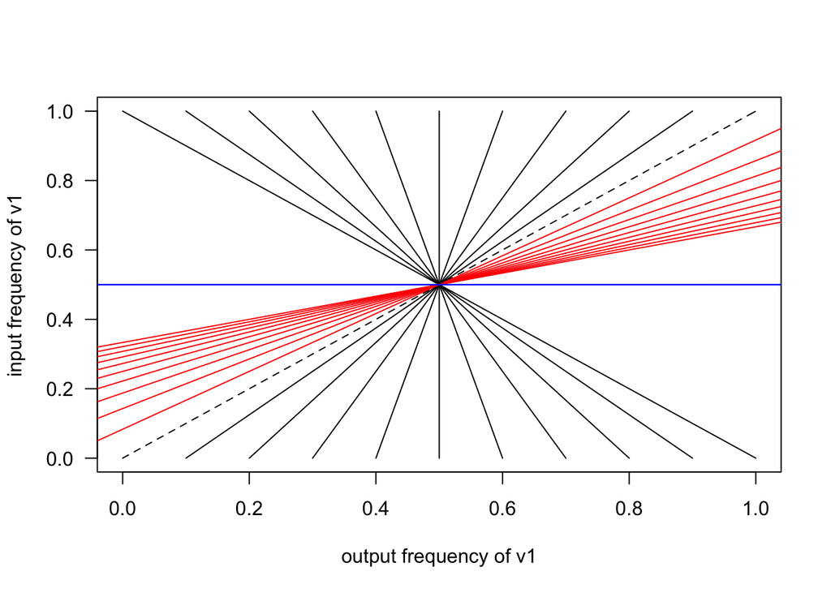

```r
qt1 <- seq(0,1,by=.01)  # all possible frequencies of v1 in generation t (resolution = by)
qt2 <- WF_expected_change(qt1,N=10,mu)  # new frequency of v1 in generation t+1
plot(qt1,qt1,las=1,type="l",lty="dashed",ylab="input frequency of v1",
         xlab="output frequency of v1",xlim=c(0,1),ylim=c(0,1))

lines(WF_expected_change(qt1,N=10,0.1),qt1)
lines(WF_expected_change(qt1,N=10,-0.1),qt1,col="red")
lines(WF_expected_change(qt1,N=10,0.2),qt1)
lines(WF_expected_change(qt1,N=10,-0.2),qt1,col="red")
lines(WF_expected_change(qt1,N=10,0.3),qt1)
lines(WF_expected_change(qt1,N=10,-0.3),qt1,col="red")
lines(WF_expected_change(qt1,N=10,0.4),qt1)
lines(WF_expected_change(qt1,N=10,-0.4),qt1,col="red")
lines(WF_expected_change(qt1,N=10,0.5),qt1)
lines(WF_expected_change(qt1,N=10,-0.5),qt1,col="red")
lines(WF_expected_change(qt1,N=10,0.6),qt1)
lines(WF_expected_change(qt1,N=10,-0.6),qt1,col="red")
lines(WF_expected_change(qt1,N=10,0.7),qt1)
lines(WF_expected_change(qt1,N=10,-0.7),qt1,col="red")
lines(WF_expected_change(qt1,N=10,0.8),qt1)
lines(WF_expected_change(qt1,N=10,-0.8),qt1,col="red")
lines(WF_expected_change(qt1,N=10,0.9),qt1)
lines(WF_expected_change(qt1,N=10,-0.9),qt1,col="red")
lines(WF_expected_change(qt1,N=10,1),qt1)
lines(WF_expected_change(qt1,N=10,-1),qt1,col="red")

# the following two lines are equal:
lines(WF_expected_change(qt1,N=10,1000),qt1,col="blue") # as mu approaches infinity
lines(WF_expected_change(qt1,N=10,-1000),qt1,col="blue") # as mu approaches negative infinity
```

## Plot other models

#### Boyd & Richerson content bias model

Equation 5.2, p.138, “Culture and the Evolutionary Process”

Assumes there are two cultural variants in the population $(v_1,v_2)$ with frequencies $p(v_1) = p$ and $q(v_2) = (1-p).$

Input:  
$p$ = the frequency of $v_1$ in generation $t$  
$B$ = the strength of the content bias for or against $v_1$  
($B = 1$ is maximum selection for, $B = -1$ is maximim selection against, $B = 0$ is no selection)

Output:  
The frequency of $v_1$ in generation $t+1$

```r
direct_bias_model <- function(p,B) {
    return(p+(B*p*(1-p)))
}

# example usage:
direct_bias_model(0.4,-1)
```

```
## [1] 0.16
```

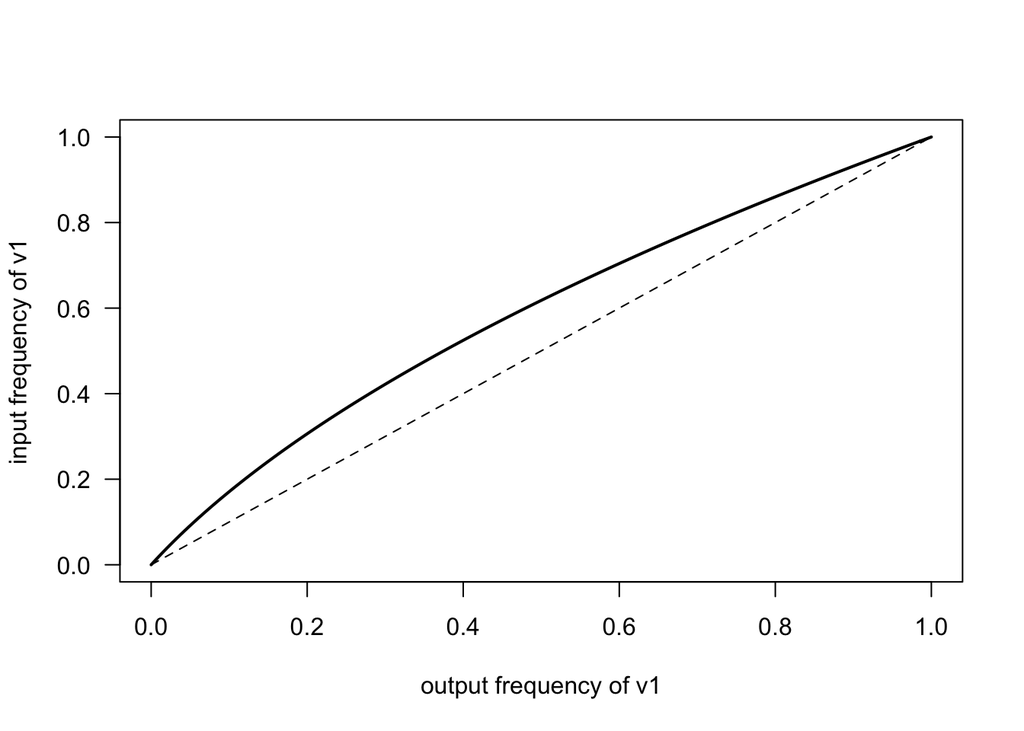

```r
# plot for full range of input p 0 to 1
y <- seq(0,1,by=.01) # the range of inputs
x <- direct_bias_model(y,0)  # neutral
x <- direct_bias_model(y,1)  # strong selection for
x <- direct_bias_model(y,-0.5)  # weak selection against

plot(x,y,las=1,type="l",lwd=2,ylab="input frequency of v1",xlab="output frequency of v1")
lines(y,y,lty="dashed")
```

#### Boyd & Richerson frequency-dependent copying model

Equation 7.1, p.208, “Culture and the Evolutionary Process”

```r
freq_dep_model <- function(p,D) {
    return(p+D*p*(1-p)*(2*p-1))
}

# example usage:
```

#### Wright Fisher drift with selection

```r
WF_selection_model <- function(in_k,out_k,N,s) {
    theta_substitute <- (in_k*(1+s)) / ((in_k*(1+s))+(N-in_k))
    #print(theta_substitute-(in_k/N))
    left = choose(N,out_k)
    middle = theta_substitute**out_k
    right = (1- theta_substitute)**(N-out_k)
    return(left * middle * right)
}
```

#### Replicator dynamics

Just plot one of the variants that’s being selected. Double check that maps on perfectly to the other selection model.

#### Define functions for analysis

Solve a transition matrix for its stationary distribution

```r
# eigvals <- eigen(t(matrix))$values
# eigvecs <- eigen(t(matrix))$vectors

stat_dist <- function(matrix) {
    vec <- eigen(t(matrix))$vectors[,1]
    return(vec/sum(vec))
}
```